# Tostan MERL Graph Reproduction

TODO make a village type conversion csv?

```r
allC <- read.csv("EF_4Pays.csv", na.strings = '---', check.names=FALSE)
village_types <- aggregate(allC$STATUVILL, list(allC$fixture_localization.village), mean)
colnames(village_types) <- c("village","village_type")
village_types$village_type <-as.factor(village_types$village_type)
levels(village_types$village_type) <- c("beneficiary", "adopted","control")
write.csv(village_types, file = "village_types.csv", row.names = FALSE)
```

Now I need to get one large data frame to use from the distinct country/period csv files.

```r
Mali <- read.csv("17 02 21 MALI_EF CG3_Questionnaire individuel-v2.csv", na.strings = '---', check.names=FALSE)
Mauri <- read.csv("17 02 21 MAUR_EF CG3_Questionnaire individuel-v2.csv", na.strings = '---', check.names=FALSE)
GB <- read.csv("17-02-21-GB_EF_CG3_Questionnaire individuel-v2.csv", na.strings = '---', check.names=FALSE)
source("clean_names.R")
source("clean_names2.R")
names(Mali) <- clean_names2(Mali)
names(Mauri) <- clean_names2(Mauri)
names(GB) <- clean_names(GB)
Mali$country <- "Mali"
Mauri$country <- "Mauritania"
GB$country <- "Guinea-Bisseau"
Mali$period <- "EF"
Mauri$period <- "EF"
GB$period <- "EF"
#total <- rbind(Mali, Mauri,GB)
#head(total$interviewer)
names(Mali)
```

```
  [1] "number"
  [2] "formid"
  [3] "fixture_localization_department"
  [4] "commune"
  [5] "village"
  [6] "type_evaluation"
  [7] "coordonnes_gps"
  [8] "interviewer"
  [9] "nbre_groupe_ethnique"
 [10] "question1"
 [11] "sexe"
 [12] "groupe_ethnique"
 [13] "connait_age"
 [14] "age_si_oui"
 [15] "appro_age"
```

[output cut: 317 more lines]

```r
#head(names(GB))
```

Now add in village codes to total$village_type

```r
dict <- read.csv("village_types.csv")
#total$village_type <- total$village
total$village_type <- with(dict, village_type[match(total$village, village)])
head(total$village_type)
```

```
[1] adopted     adopted     beneficiary adopted     adopted     beneficiary
Levels: adopted beneficiary control
```

now to figure out how to do calculations on this stuff!

```r
# Number registered for elections. Actually matches data given to me, thank goodness (except for 63 vs 161 Mali participants)
library(dplyr)
filtered <- filter(total,village_type=='beneficiary' | is.na(village_type), interviewer!='membre_simple')
grouped <- group_by(filtered, country, interviewer)
result <- summarize(grouped,
                    n = n(),
                    num_registered = sum(electoral_list_inscription=='oui', na.rm=TRUE),
                    num_total = length(!is.na(electoral_list_inscription)),
                    percent_registered = num_registered / num_total
)
result
```

| country | interviewer | n | num_registered | num_total | percent_registered |
| --- | --- | --- | --- | --- | --- |
| Guinea-Bisseau | adopte | 150 | 90 | 150 | 0.6000000 |
| Guinea-Bisseau | participant | 151 | 93 | 151 | 0.6158940 |
| Mali | adopte | 162 | 127 | 162 | 0.7839506 |
| Mali | participant | 163 | 132 | 163 | 0.8098160 |
| Mauritania | adopte | 119 | 85 | 119 | 0.7142857 |
| Mauritania | participant | 123 | 91 | 123 | 0.7398374 |

```r
# Number of children declared. Still need to see if I can filter some stuff for only one interviewer type.
# Oh! I'm getting this wrong because it's yes or no by person, not total percent of kids overall.
library(dplyr)
filtered <- filter(total, interviewer=="participant", nombre_denfants>0)
grouped <- group_by(filtered, country, interviewer, village_type)
result <- summarize(grouped,
                    n = n(),
                    tot_under_one = sum(child_under_one_declared, na.rm=TRUE),
                    tot_one_to_five = sum(child_between_1_and_5_declared, na.rm=TRUE),
                    tot_kids = sum(nombre_denfants, na.rm=TRUE),
                    percent_declared = (tot_under_one + tot_one_to_five) / tot_kids
)
result
```

| country | interviewer | village_type | n | tot_under_one | tot_one_to_five | tot_kids | percent_declared |
| --- | --- | --- | --- | --- | --- | --- | --- |
| Guinea-Bisseau | participant | beneficiary | 85 | 74 | 51 | 379 | 0.3298153 |
| Guinea-Bisseau | participant | NA | 5 | 2 | 3 | 21 | 0.2380952 |
| Mali | participant | beneficiary | 154 | 546 | 157 | 770 | 0.9129870 |
| Mali | participant | NA | 2 | 1 | 1 | 3 | 0.6666667 |
| Mauritania | participant | beneficiary | 93 | 246 | 119 | 397 | 0.9193955 |

This is an R Notebook to help reproduce graphs frequently made by MERL, using example data from Guinea.

R notebooks are a combination of code (in the grey boxes, called chunks) and surrounding text explanations. You can run the code for each chunk individually, making the graphs easily reproducible and reusable with new data.

First, let’s read in the data we want.

```r
getwd()
```

```
[1] "C:/Users/Dina/Documents/Watson/Tostan"
```

```r
d <- read.csv("Forms.csv", na.strings = '---', check.names=FALSE)
EF_data <- read.csv("17-02-21-GB_EF_CG3_Questionnaire individuel-v2.csv", na.strings = '---', check.names=FALSE)
```

Unfortunately, the variable names from the server are not very compatible with R. This code fixes the variable names.

```r
source("clean_names.R")
names(d) <- clean_names(d)
names(EF_data) <- clean_names(EF_data)
```

We can visually check and see that the variable names look right by looking at the first few varibles visually.

```r
head(names(d),10)
```

```
 [1] "number"                          "formid"                          "departement"
 [4] "commune"                         "village"                         "type_de_communaut"
 [7] "type_evaluation"                 "coordonnes_gps_latitudedegrees"  "coordonnes_gps_longitudedegrees"
[10] "coordonnes_gps_altitudemeters"
```

Hopefully, those variable names now look good. Next, we can make some graphs!

Now trying to get the data into the proper format for the graph below

```r
d$country <- "Gambia"
head(d$country,10)
```

```
 [1] "Gambia" "Gambia" "Gambia" "Gambia" "Gambia" "Gambia" "Gambia" "Gambia" "Gambia" "Gambia"
```

```r
registered_girls <- sum(d$GOUV4_nbre_fille_enregistre, na.rm=TRUE)
registered_boys <- sum(d$GOUV5_nbre_garcon_enregistre, na.rm=TRUE)
total_kids <- sum(d$nombre_denfants, na.rm=TRUE)
EB_perc <- (registered_boys + registered_girls) / total_kids
EB_perc
```

```
[1] 0.5494845
```

```r
table(d$interviewer[d$nombre_denfants>0])
```

```
membre_simple   participant
          184             1
```

```r
k1 <- sum(EF_data$child_under_one_declared[EF_data$interviewer=="participant"], na.rm=TRUE)
k2 <- sum(EF_data$child_between_1_and_5_declared[EF_data$interviewer=="participant"], na.rm=TRUE)
total_kids <- sum(EF_data$nombre_denfants[EF_data$interviewer=="participant"], na.rm=TRUE)
EF_perc <- (k1+k2) / total_kids
table(EF_data$interviewer[EF_data$nombre_denfants>0])
```

```
       adopte membre_simple   participant
          118           369            90
```

```r
country <- c('GB','GB','GB','SEN','SEN','SEN')
interviewer <- c('simple','adoptee','participant','simple','adoptee','participant')
period <- c('EB','EF','EF','EB','EF','EF')
percentage_declared <- c(.5,.5,.4,.3,.6,.2)
x <- data.frame(country, interviewer, period, percentage_declared)
blah <-ftable(xtabs(percentage_declared ~ country+period+interviewer, data = x))
library(gridExtra)
grid.table(blah)
```

[figure not shown]

```r
barplot(as.matrix(x), main="Title", xlab="Phase", ylab="Percentage", names.arg=c("EB","EF","EF"),
beside = TRUE)
legend("topright", c("First","Second","third"), cex=1.3, bty="n")
```

[output not shown]

Okay to do things with lots of factors it looks like lattice is a good choice. Explanations I liked are https://www.statmethods.net/advgraphs/trellis.html for basic plot organization https://magesblog.com/post/2012-12-04-changing-colours-and-legends-in-lattice/ for styling

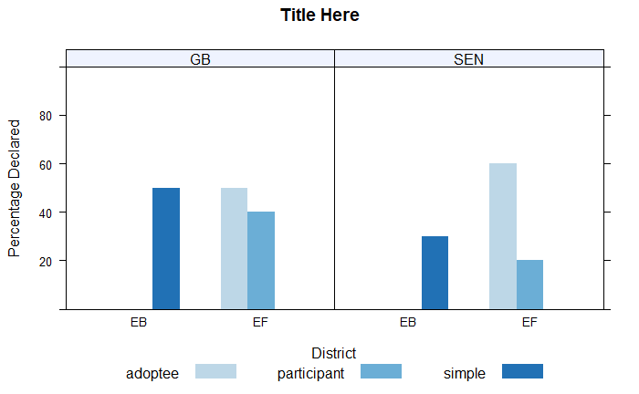

```r
library(RColorBrewer)
myColours <- brewer.pal(4,"Blues")
my.settings <- list(
  superpose.polygon=list(col=myColours[2:4], border="transparent"),
  strip.background=list(col=myColours[1]),
  strip.border=list(col="black")
)
library(lattice)
barchart(x$percentage_declared*100~x$period|x$country,
         groups=x$interviewer,data=x,
         ylim=c(0,100),
         ylab = "Percentage Declared",
         main = "Title Here",
        auto.key=list(space="bottom", columns=3, title="District", cex.title=1),
        par.settings = my.settings
        )
```